# Pràctica 2

## Presentació

En aquesta pràctica s’elabora un cas pràctic orientat a aprendre a identificar les dades rellevants per un projecte analític i usar les eines d’integració, neteja, validació i anàlisi de les mateixes. Per fer aquesta pràctica haureu de treballar en grups de fins a 3 persones, o si preferiu, també podeu fer-ho de manera individual. Haureu de lliurar un sol fitxer amb l’enllaç Github (https://github.com) on hi hagi les solucions incloent els noms dels components de l’equip. Podeu utilitzar la Wiki de Github per descriure el vostre equip i els diferents arxius que corresponen la vostra entrega. Cada membre de l’equip haurà de contribuir amb el seu usuari Github. Podeu utilitzar aquests exemples com guia:

- Exemple: https://github.com/Bengis/nba-gap-cleaning
- Exemple complex (fitxer adjunt).

## Competències

En aquesta pràctica es desenvolupen les següents competències del Màster de Data Science:

- Capacitat d'analitzar un problema en el nivell d'abstracció adequat a cada situació i aplicar les habilitats i coneixements adquirits per abordar-lo i resoldre'l.
- Capacitat per aplicar les tècniques específiques de tractament de dades (integració, transformació, neteja i validació) per al seu posterior anàlisi.

## Objectius

Els objectius concrets d’aquesta pràctica són:

- Aprendre a aplicar els coneixements adquirits i la seva capacitat de resolució de problemes en entorns nous o poc coneguts dintre de contextos més amplis o multidisciplinaris.
- Saber identificar les dades rellevants i els tractaments necessaris (integració, neteja i validació) per dur a terme un projecte analític.
- Aprendre a analitzar les dades adequadament per abordar la informació contiguda en les dades.
- Identificar la millor representació dels resultats per tal d’aportar conclusions sobre el problema plantejat en el procés analític.
- Actuar amb els principis ètics i legals relacionats amb la manipulació de dades en funció de l'àmbit d'aplicació.
- Desenvolupar les habilitats d'aprenentatge que els permetin continuar estudiant d'una manera que haurà de ser en gran manera autodirigida o autònoma.
- Desenvolupar la capacitat de cerca, gestió i ús d'informació i recursos en l'àmbit de la ciència de dades.

## Descripció de la Pràctica a realitzar

L’objectiu d’aquesta activitat serà el tractament d’un dataset, que pot ser el creat a la pràctica 1 o bé qualsevol dataset lliure disponible a Kaggle (https://www.kaggle.com). Alguns exemples de dataset amb els que podeu treballar són:

- Red Wine Quality (https://www.kaggle.com/uciml/red-wine-quality-cortez-et-al- 2009).
- Titanic: Machine Learning from Disaster (https://www.kaggle.com/c/titanic ).
- Predict Future Sales (https://www.kaggle.com/c/competitive-data-sciencepredict-future-sales/).

Els últims dos exemples corresponen a competicions actives a Kaggle de manera que, opcionalment, podrieu aprofitar el treball realitzat durant la pràctica per entrar en alguna d’aquestes competicions. Seguint les principals etapes d’un projecte analític, les diferents tasques a realitzar (i justificar) són les següents:

1. Descripció del dataset. Perquè és important i quina pregunta/problema pretèn respondre?
2. Integració i selecció de les dades d’interès a analitzar.
3. Neteja de les dades.
   - 3.1. Les dades contenen zeros o elements buits? Com gestionaries aquests casos?
   - 3.2. Identificació i tractament de valors extrems.
4. Anàlisi de les dades.
   - 4.1. Selecció dels grups de dades que es volen analitzar/comparar (planificació dels anàlisis a aplicar).
   - 4.2. Comprovació de la normalitat i homogeneïtat de la variància.
   - 4.3. Aplicació de proves estadístiques per comparar els grups de dades. En funció de les dades i de l’objectiu de l’estudi, aplicar proves de contrast d’hipòtesis, correlacions, regressions, etc.
5. Representació dels resultats a partir de taules i gràfiques.
6. Resolució del problema. A partir dels resultats obtinguts, quines són les conclusions? Els resultats permeten respondre al problema?
7. Codi: Cal adjuntar el codi, preferiblement en R, amb el que s’ha realitzat la neteja, anàlisi i representació de les dades. Si ho preferiu, també podeu treballar en Python.

## Recursos

Els següents recursos són d’utilitat per la realització de la pràctica:

- Megan Squire (2015). Clean Data. Packt Publishing Ltd.
- Jiawei Han, Micheine Kamber, Jian Pei (2012). Data mining: concepts and techniques. Morgan Kaufmann.
- Jason W. Osborne (2010). Data Cleaning Basics: Best Practices in Dealing with Extreme Scores. Newborn and Infant Nursing Reviews; 10 (1): pp. 1527-3369.
- Peter Dalgaard (2008). Introductory statistics with R. Springer Science & Business Media.
- Wes McKinney (2012). Python for Data Analysis. O’Reilley Media, Inc.
- Tutorial de Github https://guides.github.com/activities/hello-world.

## Criteris de valoració

Tots els apartat són obligatoris. La ponderació dels exercicis és la següent:

- Els apartats 1, 2 i 6 valen 0,5 punts.
- Els apartats 3,5 i 7 valen 2 punts.
- L’apartat 4 val 2,5 punts. Es valorarà la idoneïtat de les respostes, que han de ser clares i completes. Les diferents etapes han d’estar ben justificades i acompanyades del codi corresponent. També es valorarà la síntesi i claredat, a través de l’ús de comentaris, del codi resultant, així com la qualitat de les dades finals analitzades.

## Format i data de lliurament

Durant la setmana del 14 de maig el grup podrà lliurar al professor una entrega parcial opcional. Aquesta entrega parcial és molt recomanable per tal de rebre assessorament sobre la pràctica i verificar que la direcció presa és la correcta. Es lliuraran comentaris als estudiants que hagin efectuat l’entrega parcial però no comptarà per la nota de la pràctica. En l’entrega parcial els estudiants hauran de lliurar per correu electrònic (mcalvogonza@uoc.edu) l’enllaç al repositori Github amb el que hagin avançat. Pel que fa a l’entrega final, cal lliurar un únic fitxer que contingui l’enllaç a Github on hi hagi:

1. Una Wiki on hi hagi els noms dels components del grup i una descripció dels fitxers.
2. Un document Word, Open Office o PDF amb les respostes a les preguntes i els noms dels components del grup.
3. Una carpeta amb el codi generat per analitzar les dades.
4. El fitxer CSV amb les dades originals.
5. El fitxer CSV amb les dades finals analitzades. Aquest document de l’entrega final de la Pràctica 2 s’ha de lliurar a l’espai de Lliurament i Registre d’AC de l’aula abans de les 23:59 del dia 11 de juny. No s’acceptaran lliuraments fora de termini.

# 1. Descripció del dataset. Perquè és important i quina pregunta/problema pretèn respondre?

Per a la realització d'aquesta pràctica faré servir el dataset que vaig crear a la Pràctica 1. Aquest dataset conté informació sobre el nomenclàtor de la ciutat de Barcelona. Hem de tenir en compte que els noms dels carrers han anat evolucionant amb el temps i són un fidel reflex dels diversos esdeveniments tant històrics com socials, econòmics, polítics i culturals ocorreguts en aquesta ciutat. A més, la seva evolució ve marcada per diferents factors, tant de físics, tals com l’urbanisme i els diferents canvis territorials, com socials, tals com els canvis de govern o l'evolució de la pròpia societat.

La informació del dataset es troba emmagatzemada en un fitxer CSV, en el que cada fila està identificada per un índex que és únic per a cada carrer i que segueix la codificació utilitzada per l’Ajuntament de Barcelona.

Per a cada carrer s’especifiquen els següents camps:

- Codi.
- Nom oficial del carrer.
- Nom curt del carrer.
- Descripció de l’origen i història del carrer.
- Data d’aprovació.
- Noms anteriors del carrer.
- Districtes en els que el carrer està contingut.

En el seu moment la idea que vaig tenir per crear aquest dataset va ser fer-lo servir per desenvolupar una aplicació de mòbil per donar informació sobre la història dels carrers de Barcelona, però en vistes a realitzar aquesta pràctica li he vist una nova possible aplicació: estudiar l'evolució de l'assignació de noms a carrers en referència als carrers dedicats a personatges i, dintre d'aquest conjunt, els que estan dedicats a personatges femenins i masculins. Considero interessant poder estudiar l'evolució de l'assignació de noms de carrers a personatges femenins, i a partir d'aquí proposo una hipòtesi que serà la que intentaré confirmar o descartar a partir de l'estudi de les dades: a mesura que la societat ha anat evolucionant i s'ha anat donant visibilitat a la població femenina, intueixo que es deuen haver assignat més noms de carrers a personatges femenins.

Anem, doncs, a estudiar les dades per poder valorar la consistència d'aquesta hipòtesi. En cas de que quedi confirmada, pot servir per confirmar la tendència a l'assoliment de la igualtat entre sexes; en cas contrari, pot servir com a prova per animar als responsables polítics per tenir en compte la igualtat de sexes en l'assignació dels noms dels carrers.

Faré servir Jupyter amb Python, ja que aquesta combinació la trobo molt còmode per treballar en l'anàlisi i representació de les dades i per afegir l'explicació del que es va fent, de manera seqüencial.

# 2. Integració i selecció de les dades d’interès a analitzar.

Anem a veure, primer de tot, les dades que vam obtenir a la Pràctica 1. Primer de tot, importem algunes llibreries que farem servir, i forcem les gràfiques a que es vegin incrustades en aquest full de Jupyter.

```python
import pandas as pd
import numpy as np
import matplotlib.pyplot as plt

%matplotlib inline
```

Importem el dataset generat a la Pràctica 1 i l'emmagatzamem en un dataframe de pandas.

```python
nomenclator_df = pd.read_csv("BCN_nomenclator.csv", encoding="utf8", sep='\t')
```

Anem a veure l'aspecte d'aquestes dades.

```python
nomenclator_df.head(5)
```

|  | Unnamed: 0 | CODI_VIA | TIPUS_VIA | NOM_OFICIAL | NOM_CURT | DESCRIPCIO | DATA_APROVACIO | NOMS_ANTERIORS | DISTRICTES |
| --- | --- | --- | --- | --- | --- | --- | --- | --- | --- |
| 0 | 0 | 102 | C | Carrer dels Llebrencs | Llebrencs | Nom popular que es dóna als nascuts a Vallvidr... | 29/06/1987 | Lletra A (Vallvidrera) | SARRIÀ-SANT GERVASI (05) |
| 1 | 1 | 180 | C | Carrer A Zona Franca | A | Carrer del polígon industrial del Consorci de ... | 16/02/1968 | NaN | SANTS-MONTJUÏC (03) |
| 2 | 2 | 204 | C | Carrer de Guerau de Liost | Guerau de Liost | Jaume Bofill i Mates (Olot, 1878 - Barcelona, ... | 29/07/1987 | Ptge. lletra A (Vallvidrera) | SARRIÀ-SANT GERVASI (05) |
| 3 | 3 | 306 | C | Carrer de l'Abat Odó | Abat Odó | Abat Odó (? - 1010). Bisbe de Girona (995) i a... | (Abans de 1940) | Otto, 1939; Abat Odó, 1934; Otto, 1907; Santa ... | SANT ANDREU (09) |
| 4 | 4 | 408 | C | Carrer de l'Abat Samsó | Abat Samsó | Miquel Samsó (Girona, 1430 - ?). Abat de Sant ... | 07/03/1939 | Bernat Cavaller, 1931; Abat Samsó, 1927; Berna... | SARRIÀ-SANT GERVASI (05) |

Per a fer el nostre estudi necessitem saber quin carrers estan dedicats a persones, i també necessitem saber el sexe d'aquestes persones. Com podem fer-ho per aconseguir aquesta informació?

A la fila 2 veiem un cas de carrer dedicat a una persona. Anem a veure el camp *DESCRIPCIO*.

```python
nomenclator_df.at[2, 'DESCRIPCIO']
```

```
'Jaume Bofill i Mates (Olot, 1878 - Barcelona, 1933). Poeta, polític i periodista conegut amb el pseudònim de Guerau de Liost.'
```

Aquest camp comença amb el nom de la persona i, entre parèntesi, apareix la informació sobre lloc i data de naixement i mort. Per tant, considero que el que podem fer és aprofitar aquesta informació per fer les següents tasques:

- Detectar les files que corresponen a carrers dedicats a persones.
- Extreure el nom de la persona i afegir al dataset un nou camp pel nom de la persona: _NOM*P*.
- Buscar per internet algun llistat de noms de persones i el seu sexe, i a partir d'aquestes dades, generar un altre camp _SEXE*P* amb el sexe de la persona a la que es dedica el nom.
- Extreure la informació de l'any en que es va aprovar el nom del carrer, a partir del camp _DATA*APROVACIO*.

Així doncs, primer de tot realitzarem la neteja de les dades (apartat 3) i la seva anàlisi (apartat 4), que inclouran aquestes tasques que acabem d'esmentar.

# 3. Neteja de les dades.

## 3.1. Les dades contenen zeros o elements buits? Com gestionaries aquests casos?

## 3.2. Identificació i tractament de valors extrems.

Primer de tot, anem a veure quantes files tenim al dataframe:

```python
len(nomenclator_df)
```

```
4622
```

Molt bé, tenim 4622 registres.

Ara, anem a el·liminar les columnes que considerem que no són necessàries pel nostre estudi: *Unnamed: 0*, _CODI*VIA*, _TIPUS*VIA*, _NOMS*ANTERIORS* i *DISTRICTES*.

```python
nomenclator_df = nomenclator_df.drop(['Unnamed: 0', 'CODI_VIA', 'TIPUS_VIA', 'NOMS_ANTERIORS', 'DISTRICTES'], axis=1)
```

```python
nomenclator_df.head(5)
```

|  | NOM_OFICIAL | NOM_CURT | DESCRIPCIO | DATA_APROVACIO |
| --- | --- | --- | --- | --- |
| 0 | Carrer dels Llebrencs | Llebrencs | Nom popular que es dóna als nascuts a Vallvidr... | 29/06/1987 |
| 1 | Carrer A Zona Franca | A | Carrer del polígon industrial del Consorci de ... | 16/02/1968 |
| 2 | Carrer de Guerau de Liost | Guerau de Liost | Jaume Bofill i Mates (Olot, 1878 - Barcelona, ... | 29/07/1987 |
| 3 | Carrer de l'Abat Odó | Abat Odó | Abat Odó (? - 1010). Bisbe de Girona (995) i a... | (Abans de 1940) |
| 4 | Carrer de l'Abat Samsó | Abat Samsó | Miquel Samsó (Girona, 1430 - ?). Abat de Sant ... | 07/03/1939 |

Anem a veure primer les dades estadístiques del dataframe:

```python
nomenclator_df.describe()
```

|  | NOM_OFICIAL | NOM_CURT | DESCRIPCIO | DATA_APROVACIO |
| --- | --- | --- | --- | --- |
| count | 4622 | 4622 | 4489 | 3888 |
| unique | 4622 | 4622 | 4308 | 751 |
| top | Plaça de Boyeros | Plta Pedraforca | Carrer del polígon industrial del Consorci de ... | (Abans de 1900) |
| freq | 1 | 1 | 30 | 420 |

Veiem que de les 4622 files, tenim que a les columnes _NOM*OFICIAL* i _NOM*CURT* tenim 4622, és a dir, que no tenim valors buits. En canvi, a la columna *DESCRIPCIO* tenim 4489 registres i a _DATA*APROVACIO* en tenim 3888, la qual cosa ens diu que aquestes columnes tenen valors buits. Anem a confirmar-ho:

```python
print(len(nomenclator_df[nomenclator_df['DESCRIPCIO'].isnull()]))
print(len(nomenclator_df[nomenclator_df['DATA_APROVACIO'].isnull()]))
```

```
133
734
```

Efectivament, tenim 133 files amb el camp *DESCRIPCIO* buit i 734 amb el camp _DATA*APROVACIO* buit. Com que ens interessa veure l'evolució en el temps de l'assignació dels noms de carrers a persones, necessitem considerar només els registres que tenen valors en aquests dos camps. Per tant, decideixo sel·leccionar només els registres que tenen aquests dos camps no buits:

```python
nomenclator_df = nomenclator_df[nomenclator_df['DESCRIPCIO'].notnull() & nomenclator_df['DATA_APROVACIO'].notnull()]
```

```python
nomenclator_df.describe()
```

|  | NOM_OFICIAL | NOM_CURT | DESCRIPCIO | DATA_APROVACIO |
| --- | --- | --- | --- | --- |
| count | 3876 | 3876 | 3876 | 3876 |
| unique | 3876 | 3876 | 3749 | 748 |
| top | Carrer de Saldes | Peracamps | Carrer del polígon industrial del Consorci de ... | (Abans de 1900) |
| freq | 1 | 1 | 19 | 420 |

Perfecte, ara veiem que ja tenim només registres en els que els camps *DESCRIPCIO* i _DATA*APROVACIO* no són buits.

A continuació, hauriem de veure si tenim valors extrems. Tal com tenim les dades en aquest moment no tenim possibilitat de saber si tenim valors extrems, ja que no tenim camps numèrics. Més endavant, al següent apartat, afegirem alguns camps nous, dels quals n'hi ha un, el de l'any d'aprovació del nom del carrer, que serà numèric. Per tant, deixo la detecció de valors extrems pel moment en que haguem afegit aquesta nova columna.

# 4. Anàlisi de les dades.

## 4.1. Selecció dels grups de dades que es volen analitzar/comparar (planificació dels anàlisis a aplicar).

Primer de tot, anem a afegir les 3 columnes que haviem esmentat abans:

```python
nomenclator_df = nomenclator_df.append(pd.DataFrame(columns=["ANY"], dtype=int))
```

```python
nomenclator_df = nomenclator_df.append(pd.DataFrame(columns=["NOM_P"], dtype=str))
```

```python
nomenclator_df = nomenclator_df.append(pd.DataFrame(columns=["SEXE_P"], dtype=str))
```

Un cop creades, les omplim amb valors per defecte:

```python
nomenclator_df["ANY"] = np.NaN
```

```python
nomenclator_df["NOM_P"] = ""
```

```python
nomenclator_df["SEXE_P"] = ""
```

Anem a veure un exemple del que tenim fins ara:

```python
nomenclator_df.head(5)
```

|  | ANY | DATA_APROVACIO | DESCRIPCIO | NOM_CURT | NOM_OFICIAL | NOM_P | SEXE_P |
| --- | --- | --- | --- | --- | --- | --- | --- |
| 0 | NaN | 29/06/1987 | Nom popular que es dóna als nascuts a Vallvidr... | Llebrencs | Carrer dels Llebrencs |  |  |
| 1 | NaN | 16/02/1968 | Carrer del polígon industrial del Consorci de ... | A | Carrer A Zona Franca |  |  |
| 2 | NaN | 29/07/1987 | Jaume Bofill i Mates (Olot, 1878 - Barcelona, ... | Guerau de Liost | Carrer de Guerau de Liost |  |  |
| 3 | NaN | (Abans de 1940) | Abat Odó (? - 1010). Bisbe de Girona (995) i a... | Abat Odó | Carrer de l'Abat Odó |  |  |
| 4 | NaN | 07/03/1939 | Miquel Samsó (Girona, 1430 - ?). Abat de Sant ... | Abat Samsó | Carrer de l'Abat Samsó |  |  |

A continuació, anem a emplenar la columna *ANY* a partir de les dades que tenim a la columna _DATA*APROVACIO*:

```python
for index, row in nomenclator_df.iterrows():
    try:
        any = row['DATA_APROVACIO'].split('/')[2]
        nomenclator_df.at[index, 'ANY'] = int(any)
    except:
        pass
    try:
        any = nomenclator_df.at[3, 'DATA_APROVACIO'].split(' ')[2]
        nomenclator_df.at[3, 'ANY',] = any[:-1]
    except:
        pass
```

```python
nomenclator_df.head(5)
```

|  | ANY | DATA_APROVACIO | DESCRIPCIO | NOM_CURT | NOM_OFICIAL | NOM_P | SEXE_P |
| --- | --- | --- | --- | --- | --- | --- | --- |
| 0 | 1987.0 | 29/06/1987 | Nom popular que es dóna als nascuts a Vallvidr... | Llebrencs | Carrer dels Llebrencs |  |  |
| 1 | 1968.0 | 16/02/1968 | Carrer del polígon industrial del Consorci de ... | A | Carrer A Zona Franca |  |  |
| 2 | 1987.0 | 29/07/1987 | Jaume Bofill i Mates (Olot, 1878 - Barcelona, ... | Guerau de Liost | Carrer de Guerau de Liost |  |  |
| 3 | 1940.0 | (Abans de 1940) | Abat Odó (? - 1010). Bisbe de Girona (995) i a... | Abat Odó | Carrer de l'Abat Odó |  |  |
| 4 | 1939.0 | 07/03/1939 | Miquel Samsó (Girona, 1430 - ?). Abat de Sant ... | Abat Samsó | Carrer de l'Abat Samsó |  |  |

Un cop hem emplenat la columna *ANY*, anem a veure quants valors diferents hi ha i mostrem també alguns valors estadístics:

```python
len(nomenclator_df.groupby('ANY').size())
```

```
133
```

```python
nomenclator_df.describe()
```

|  | ANY |
| --- | --- |
| count | 2913.000000 |
| mean | 1960.455887 |
| std | 36.204863 |
| min | 1848.000000 |
| 25% | NaN |
| 50% | NaN |
| 75% | NaN |
| max | 2015.000000 |

Veiem que hi ha valors per 133 anys diferents, però tenim valors NaN. El que farem a continuació serà sel·leccionar només els registres amb valors correctes per l'any:

```python
len(nomenclator_df[nomenclator_df['ANY'].notnull()])
```

```
2913
```

```python
len(nomenclator_df[nomenclator_df['ANY'].isnull()])
```

```
963
```

Veiem que tenim 963 files amb valors nuls i 2913 amb valors no nuls. Sel·leccionem només els no nuls:

```python
nomenclator_df = nomenclator_df[nomenclator_df['ANY'].notnull()]
```

Anem a veure el valors estadístics un cop hem tret els valor nuls:

```python
nomenclator_df.describe()
```

|  | ANY |
| --- | --- |
| count | 2913.000000 |
| mean | 1960.455887 |
| std | 36.204863 |
| min | 1848.000000 |
| 25% | 1932.000000 |
| 50% | 1960.000000 |
| 75% | 1993.000000 |
| max | 2015.000000 |

Veiem que tenim carrers que se'ls hi ha assignat un nom entre els anys 1848 i 2015. Anem a representar-ho gràficament, aprofitant tota l'amplada del full:

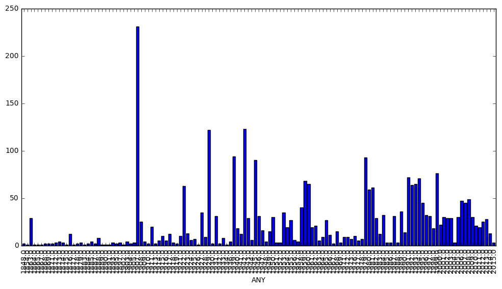

```python
plt.rcParams['figure.figsize'] = (12, 6)
nomenclator_df.groupby(['ANY']).size().plot.bar(color=['b'], width=0.75)
```

La representació gràfica ja ens dóna una idea de l'aspecte de les dades. A priori, no semble que hi hagi valors extrems, els valors dels anys són compatibles amb la natura de les dades.

Anem ara a emplenar la columna _NOM*P*. El que veig és que el camp *DESCRIPCIO* té un format concret pel cas en el que el nom del carrer es tracti d'una persona: En la primera frase de la descripció tenim el nom de la persona i, entre parèntesi, el lloc i data de naixement i mort del personatge. Aprofitant això, el que faig és considerar les descripcons que tenen aquest format i, en aquests casos, triar el nom i afegir-lo a la columna _NOM*P*:

```python
for index, row in nomenclator_df.iterrows():
    descripcio = str(row['DESCRIPCIO']).split('). ')
    if len(descripcio) > 1:
        nom_personatge = descripcio[0].split(" ")[0]
        nomenclator_df.at[index, 'NOM_P'] = nom_personatge
```

A mode d'exemple dels resultats, anem a veure les primeres files:

```python
nomenclator_df.head(5)
```

|  | ANY | DATA_APROVACIO | DESCRIPCIO | NOM_CURT | NOM_OFICIAL | NOM_P | SEXE_P |
| --- | --- | --- | --- | --- | --- | --- | --- |
| 0 | 1987.0 | 29/06/1987 | Nom popular que es dóna als nascuts a Vallvidr... | Llebrencs | Carrer dels Llebrencs |  |  |
| 1 | 1968.0 | 16/02/1968 | Carrer del polígon industrial del Consorci de ... | A | Carrer A Zona Franca |  |  |
| 2 | 1987.0 | 29/07/1987 | Jaume Bofill i Mates (Olot, 1878 - Barcelona, ... | Guerau de Liost | Carrer de Guerau de Liost | Jaume |  |
| 3 | 1940.0 | (Abans de 1940) | Abat Odó (? - 1010). Bisbe de Girona (995) i a... | Abat Odó | Carrer de l'Abat Odó | Abat |  |
| 4 | 1939.0 | 07/03/1939 | Miquel Samsó (Girona, 1430 - ?). Abat de Sant ... | Abat Samsó | Carrer de l'Abat Samsó | Miquel |  |

Veiem que, efectivament, a la columna _NOM*P* hi apareixen noms en alguns casos. El que podem fer ara és mirar quants de casos hem trobat en que el carrer està dedicat a una persona:

```python
len(nomenclator_df[nomenclator_df['NOM_P'] != ""])
```

```
1277
```

```python
len(nomenclator_df[nomenclator_df['NOM_P'] == ""])
```

```
1636
```

Tenim un total de 1277 carrers amb factibles noms de persona i 1636 que no ho són. El que farem serà sel·leccionar només els que contenen noms de persona:

```python
nomenclator_df = nomenclator_df[nomenclator_df['NOM_P'] != ""]
```

```python
nomenclator_df.describe()
```

|  | ANY |
| --- | --- |
| count | 1277.000000 |
| mean | 1957.371182 |
| std | 36.994408 |
| min | 1863.000000 |
| 25% | 1929.000000 |
| 50% | 1959.000000 |
| 75% | 1993.000000 |
| max | 2014.000000 |

Veiem que ara tenim 1277 registres, en els que l'any va des de 1863 fins a 2014. La mitjana es troba a 1957.37 amb una desviacó estàndard de 36.99.

Anem a representar-ho gràficament:

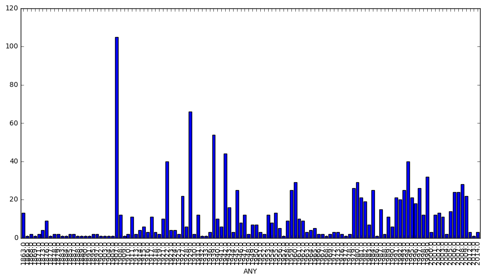

```python
plt.rcParams['figure.figsize'] = (12, 6)
nomenclator_df.groupby(['ANY']).size().plot.bar(color=['b'], width=0.75)
```

Ara anem a intentar assignar el sexe als personatges a partir del seu nom. Per fer-ho, necessitem algun llistat en el que apareguin noms i el seu corresponent sexe. Buscant per internet he trobat que al web de l'Institut d'Estadística de Catalunya existeixen uns llistats molt adients (https://www.idescat.cat/nadons/) que es poden descarregar i que contenen els noms dels nadons nascuts a Catalunya als darrers anys, especificant el sexe i la freqüencia d'assignació d'aquest nom. Pot ser un bon punt de partida. Veiem que hi ha dades pels anys entre 1997 i 2016. Descarrego el fitxer corresponent a 2016 i l'emmagatzemo en una llista:

```python
dades_catala = [line.rstrip('\n') for line in open('s0a0rani1y2016lca.csv')]
```

Anem a veure el seu aspecte:

```python
dades_catala[:10]
```

```
['Noms dels nadons. 2016;;;;',
 'Catalunya;;;;',
 "Font: Idescat, a partir de l'estadística de naixements.;;;;",
 "Nota: el ‰ ha estat calculat sobre el total de nascuts vius a l'any i en el lloc de residència seleccionats.;;;;",
 'Nota: Només es mostren els noms de freqüència igual o superior a 4.;;;;',
 "Institut d'Estadística de Catalunya;;;;",
 'http://www.idescat.cat/nadons/;;;;',
 'Pos.;Sexe;Nom;Rànquing. Freqüència;Rànquing. ‰',
 '1;H;MARC;832;12,12',
 '2;D;MARTINA;702;10,23']
```

Veiem com les dades d'interès comenen a partir de la novena fila. Per tant, sel·leccionem les dades d'interès i prescindim de les 8 primeres files:

```python
dades_catala = dades_catala[8:]
```

```python
dades_catala[:10]
```

```
['1;H;MARC;832;12,12',
 '2;D;MARTINA;702;10,23',
 '3;H;ÀLEX/ÁLEX;656;9,56',
 '4;D;JÚLIA/JULIA;649;9,46',
 '5;D;LAIA;582;8,48',
 '6;D;LUCÍA;573;8,35',
 '7;D;MARIA/MARÍA;566;8,25',
 '8;H;JAN;562;8,19',
 '9;H;MARTÍ;557;8,12',
 '10;H;HUGO;553;8,06']
```

En aquesta llista, cada valor conté un string on, separats per ";", tenim un codi, el sexe (H o D, home o dona), el nom, la freqüència i altres dades sense interès.

```python
len(dades_catala)
```

```
1406
```

Tenim 1406 noms. Ara el que farem serà obtenir les dades d'interès en el format adequat. El que farem serà crear dues llistes, una per cada sexe, en les que emmagatzemarem els noms per cada sexe. A més, guardarem aquests noms en el mateix format en que apareixen a les nostres dades, en minúscula i amb la primera lletra en majúscula:

```python
noms_femenins_catala_list = []
noms_masculins_catala_list = []
```

```python
for line in dades_catala:
    line_list = line.split(';')
    sexe = line_list[1]
    noms = line_list[2].split('/')
    for nom in noms:
        if sexe == 'D':
            noms_femenins_catala_list.append(nom.capitalize())
        elif sexe == 'H':
            noms_masculins_catala_list.append(nom.capitalize())
```

```python
print(len(noms_femenins_catala_list))
print(len(noms_masculins_catala_list))
```

```
843
716
```

Veiem que tenim 843 noms femenins i 716 de masculins. Anem a veure els primers valors de les llistes creades:

```python
noms_femenins_catala_list[:10]
```

```
['Martina',
 'Júlia',
 'Julia',
 'Laia',
 'Lucía',
 'Maria',
 'María',
 'Emma',
 'Noa',
 'Paula']
```

```python
noms_masculins_catala_list[:10]
```

```
['Marc',
 'Àlex',
 'Álex',
 'Jan',
 'Martí',
 'Hugo',
 'Biel',
 'Eric',
 'Èric',
 'Éric']
```

Creem uns conjunts a partir de les llistes, ja que els conjunts el·liminen duplicats i augmenten la velocitat de lectura de dades:

```python
noms_femenins_catala_set = set(noms_femenins_catala_list)
noms_masculins_catala_set = set(noms_masculins_catala_list)
```

Ara creem una funció qua assigna el sexe a cada nom del nostre dataframe. Si no trobem el nom a cap dels dos conjunts, li assignem el valor "i", és a dir, indeterminat:

```python
def assignar_sexe():
    for index, row in nomenclator_df.iterrows():
        nom_personatge = row['NOM_P']
        if nom_personatge:
            nom_personatge = nom_personatge.strip()

            if nom_personatge in noms_femenins_catala_set:
                nomenclator_df.at[index, 'SEXE_P'] = 'F'
            elif nom_personatge in noms_masculins_catala_set:
                nomenclator_df.at[index, 'SEXE_P'] = 'M'

            else:
                nomenclator_df.at[index, 'SEXE_P'] = 'i'

assignar_sexe()
```

Visualitzem els resultats obtinguts:

```python
nomenclator_df.head(10)
```

|  | ANY | DATA_APROVACIO | DESCRIPCIO | NOM_CURT | NOM_OFICIAL | NOM_P | SEXE_P |
| --- | --- | --- | --- | --- | --- | --- | --- |
| 2 | 1987.0 | 29/07/1987 | Jaume Bofill i Mates (Olot, 1878 - Barcelona, ... | Guerau de Liost | Carrer de Guerau de Liost | Jaume | M |
| 3 | 1940.0 | (Abans de 1940) | Abat Odó (? - 1010). Bisbe de Girona (995) i a... | Abat Odó | Carrer de l'Abat Odó | Abat | i |
| 4 | 1939.0 | 07/03/1939 | Miquel Samsó (Girona, 1430 - ?). Abat de Sant ... | Abat Samsó | Carrer de l'Abat Samsó | Miquel | M |
| 6 | 1931.0 | 25/09/1931 | Sor Sobirana d'Olzet (? - 1336). Primera abade... | Abadessa Olzet | Carrer de l'Abadessa Olzet | Sor | i |
| 8 | 1950.0 | 15/11/1950 | Abd el-Kader (Guetna, 1808 - Damasc, 1883). Em... | Abd el-Kader | Carrer d'Abd el-Kader | Abd | i |
| 9 | 1922.0 | 21/06/1922 | Abdó Terradas i Pulí (Figueres, 1812 - Medina ... | Abdó Terradas | Carrer d'Abdó Terradas | Abdó | i |
| 11 | 1982.0 | 26/03/1982 | Manuel Ballbé i Prunés (Barcelona, 1920 - 1961... | Manuel Ballbé | Carrer de Manuel Ballbé | Manuel | M |
| 18 | 1942.0 | 07/07/1942 | Francisco Morano Moreno (Madrid, 1876 - Barcel... | Actor Morano | Carrer de l'Actor Morano | Francisco | M |
| 19 | 1942.0 | 07/07/1942 | María Álvarez Tubau (Madrid, 1854 - 1914). Act... | Actriu Tubau | Carrer de l'Actriu Tubau | María | F |
| 20 | 1982.0 | 28/07/1982 | Adolf Florensa i Ferrer (Lleida, 1889 - Barcel... | Adolf Florensa | Carrer d'Adolf Florensa | Adolf | i |

Molt bé, ara veiem que la columna_SEXE*P* ja ha estat emplenada. Anem a agrupar els valors obtinguts segons sexe:

```python
nomenclator_df.groupby(['SEXE_P']).size()
```

```
SEXE_P
F    102
M    773
i    402
dtype: int64
```

Veiem que tenim 102 noms femenins, 773 masculins i 402 indeterminats. Primer de tot, ja veiem un fet prou significatiu: hi ha gairebé 8 vegades més noms masculins que femenins.

També veiem que tenim molts de noms indeterminats, què podem fer per reduir aquest valor? Una possible solució podria ser augmentar les llistes de noms masculins i femenins. Buscant per internet he trobat un altre llistat a https://github.com/ferhatelmas/sexmachine, molt interessant, amb noms de tot el món, amb la probabilitat de que el nom sigui masculí o femení. El descarrego i a continuació l'emmagatzemo en una llista:

```python
dades_internacional = [line.rstrip('\n') for line in open('nam_dict.txt')]
```

Mirant al fitxer TXT veig que les dades d'interès començen a la fila 363. Agafo només aquestes dades:

```python
dades_internacional = dades_internacional[362:]
```

```python
dades_internacional[:10]
```

```
['M  Aad                                  4                                             $',
 'M  Aadam                                          1                                   $',
 'F  Aadje                                1                                             $',
 'M  Ådne                      +                 1                                      $',
 'M  Aadu                                           12                                  $',
 '?F Aaf                                  1                                             $',
 'F  Aafke                                4                                             $',
 '?  Aafke                                 1                                            $',
 'F  Aafkea                                1                                            $',
 'M  Aafko                                1                                             $']
```

Veiem que la llista conté strings en els que en cada un, el primer valor és el sexe i el segon és el nom. El sexe pot ser M si es másculí, ?M o 1M si és majoritàriament masculí, F si és femení, ?F o 1F si és majoritàriament femení i ? si és indeterminat. El que faré serà generar dues llistes en les que en una s'hi emmagatzemaran els noms masculins o majoritàriament masculins i en l'altra s'hi emmagatzemaran els noms femenins o majoritàriament masculins:

```python
noms_femenins_internacional_list = []
noms_masculins_internacional_list = []
```

Ara omplim ambdues llistes a partir de les dades obtingudes:

```python
for line in dades_internacional:
    dades_list = line.split(' ')
    sexe = dades_list[0]
    if dades_list[1]:
        nom = dades_list[1]
    else:
        nom = dades_list[2]
    if sexe in ["F", "?F", "1F"]:
        noms_femenins_internacional_list.append(nom)
    elif sexe in ["M", "?M", "1M"]:
        noms_masculins_internacional_list.append(nom)
```

```python
len(noms_femenins_internacional_list)
```

```
19181
```

```python
len(noms_masculins_internacional_list)
```

```
20288
```

Veiem que tenim 19181 noms femenins i 20288 noms masculins. Creem ara uns conjunts a partir d'aquestes dues llistes que hem creat:

```python
noms_femenins_internacional_set = set(noms_femenins_internacional_list)
noms_masculins_internacional_set = set(noms_masculins_internacional_list)
```

```python
len(noms_femenins_internacional_set)
```

```
18594
```

```python
len(noms_masculins_internacional_set)
```

```
19692
```

Un cop trets els valors duplicats, tenim 18594 noms femenins i 19692 masculins. Són molts de noms; sembla que poden ser unes dades prou interessants per intentar disminuir el nombre de noms amb sexe indeterminat al nostre dataframe.

Ara redefinim la funció per assignar el sexe, ara incloent-hi aquests conjunts de noms internacionals.

```python
def assignar_sexe_2():
    for index, row in nomenclator_df.iterrows():
        nom_personatge = row['NOM_P']
        if nom_personatge:
            nom_personatge = nom_personatge.strip()

            if nom_personatge in noms_femenins_catala_set:
                nomenclator_df.at[index, 'SEXE_P'] = 'F'
            elif nom_personatge in noms_masculins_catala_set:
                nomenclator_df.at[index, 'SEXE_P'] = 'M'
            elif nom_personatge in noms_femenins_internacional_set:
                nomenclator_df.at[index, 'SEXE_P'] = 'F'
            elif nom_personatge in noms_masculins_internacional_set:
                nomenclator_df.at[index, 'SEXE_P'] = 'M'
            else:
                nomenclator_df.at[index, 'SEXE_P'] = 'i'

assignar_sexe_2()
```

En la funció per cada nom primer es mira si es troba en els conjunts amb noms obtinguts a catalunya, i si no es troba, es busca als conjunts amb noms internacionals. He considerat adient fer-ho així per resoldre més satisfactòriament els casos en que un mateix nom pot ser masculí o femení, depenent de la zona geogràfica. Per exemple, "Joan" a Catalunya és un nom masculí, però als països de parla anglesa aquest nom és femení. En aquest cas, si prioritzem les dades catalanes enfront de les internacionals, el nom serà assignat al sexe adient, però si es prioritzessin les dades internacionals el sexe quedaria mal assignat:

```python
print('Joan' in noms_femenins_catala_set)
print('Joan' in noms_masculins_catala_set)
print('Joan' in noms_femenins_internacional_set)
print('Joan' in noms_masculins_internacional_set)
```

```
False
True
True
True
```

Anem a veure si hem aconseguit reduir el nombre de valors indeterminats:

```python
nomenclator_df.groupby(['SEXE_P']).size()
```

```
SEXE_P
F    162
M    900
i    215
dtype: int64
```

Efectivament, hem obtingut una millora, hem passat de 102 noms femenins, 773 masculins i 402 indeterminats a 162 noms femenins, 900 masculins i 215 indeterminats. Hem aconseguit reduir a gairebé la meitat el nombre d'indeterminats. Anem a veure aquests indeterminats:

```python
i_type = nomenclator_df.loc[nomenclator_df['SEXE_P'] == 'i']['NOM_P']
```

```python
len(i_type)
```

```
215
```

```python
len(set(i_type))
```

```
136
```

Tenim 215 indeterminats que corresponen a 136 valors únics. Anem a veure'ns alguns:

```python
i_type[:20]
```

```
3              Abat
6               Sor
9              Abdó
24            Publi
40           Agustí
43             Cala
60           Ciutat
80            Regió
83            Illes
84          Domènec
154             Pic
164             Pel
216       L'animal.
237        Armengol
246      Arquímedes
280          Ausiàs
315         Baldiri
337         Caseria
375    Coexisteixen
380           Marià
Name: NOM_P, dtype: object
```

Veiem que els fet de que siguin indeterminats es deu a diversos motius. En alguns casos, es tracta de noms molt poc comuns o bé antics. En altres casos no es tracta de noms de persona sinó de llocs geogràfics, i això es deu a que el criteri que hem utilitzat per triar el nom a partir de la descripció també tria aquesta mena de noms. Altres casos es tracta de títols nobiliaris o eclessiàstics. Amb només 136 valors, seria factible fer una assignació manual d'aquests casos. Si el que volguéssim fos obtenir dades exactes, això és el que fariem, però com que només volem veure tendències, amb les dades que tenim ja en tenim ben prou.

Anem ara a emmagatzemar aquestes dades del dataframe en un fitxer CSV:

```python
nomenclator_df.to_csv('dones_carrers_BCN.csv', sep='\t', encoding='utf-8')
```

# 5. Representació dels resultats a partir de taules i gràfiques.

Anem ara a representar gràficament el que hem obtingut:

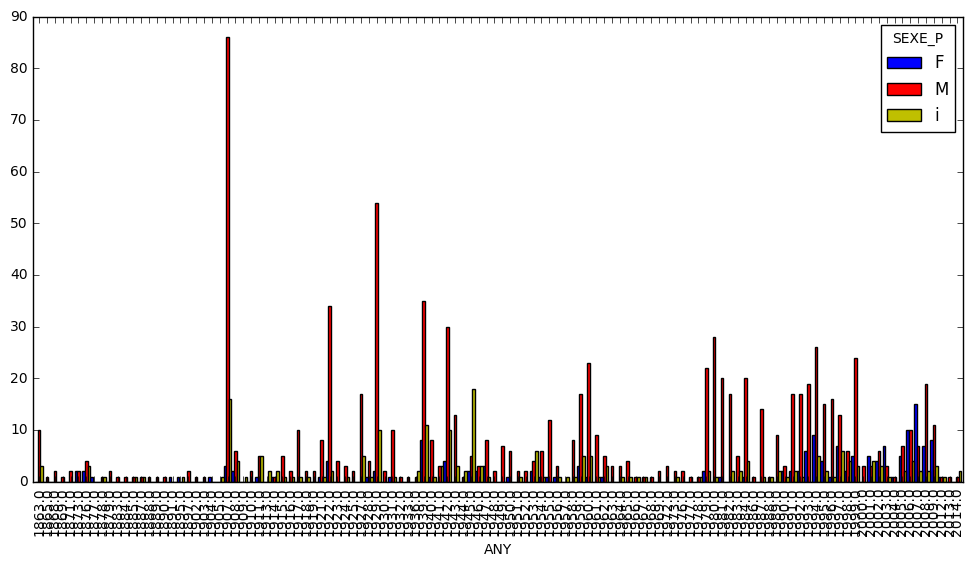

```python
nomen_df = nomenclator_df
plt.rcParams['figure.figsize'] = (12, 6)
nomen_df.groupby(['ANY','SEXE_P']).size().unstack(fill_value=0).plot.bar(color=['b', 'r', 'y'], width=1)
```

Fem algunes ampliacions d'aquestes gràfiques per veure millor els resultats:

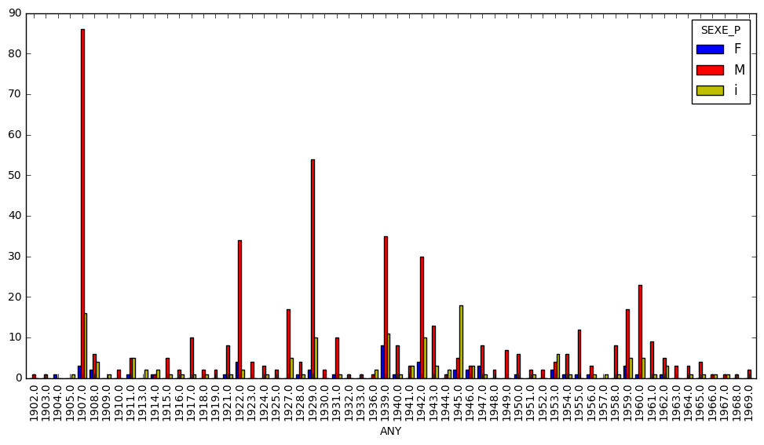

```python
nomen_df[(nomen_df['ANY'] > 1900) & (nomen_df['ANY'] < 1970)].groupby(['ANY','SEXE_P']).size().unstack(fill_value=0).plot.bar(color=['b', 'r', 'y'], width=0.75)
```

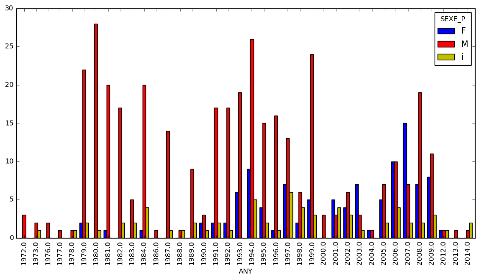

```python
nomen_df[nomen_df['ANY'] >= 1970].groupby(['ANY','SEXE_P']).size().unstack(fill_value=0).plot.bar(color=['b', 'r', 'y'], width=0.75)
```

Mostrem una nova gràfica, amb el rati entre noms de carrers femenins enfront de noms masculins, per cada any. Creem un nou dataframe per poder crear una nova columna a mb el rati:

```python
any_sexe_df = nomenclator_df.groupby(['ANY', 'SEXE_P']).size().unstack(fill_value=0)
any_sexe_df = any_sexe_df[['F', 'M']].astype(float)
any_sexe_df = any_sexe_df.append(pd.DataFrame(columns=["RATIO"], dtype=float))
```

```python
for index, row in any_sexe_df.iterrows():
    num_F = row['F']
    num_M = row['M']
    if num_F > 0 or num_M > 0:
        if num_F == 0:
            ratio = 0.0 / num_M
        elif num_M == 0:
            ratio = num_F / 0.5
        else:
            ratio = 1.0 * num_F / num_M
    else:
        ratio = 0
    any_sexe_df.at[index, 'RATIO'] = ratio
```

Per poder calcular el rati en els casos en que el nombre de noms masculins sigui zero el que faig és considerar que aquest valor és 0.5.

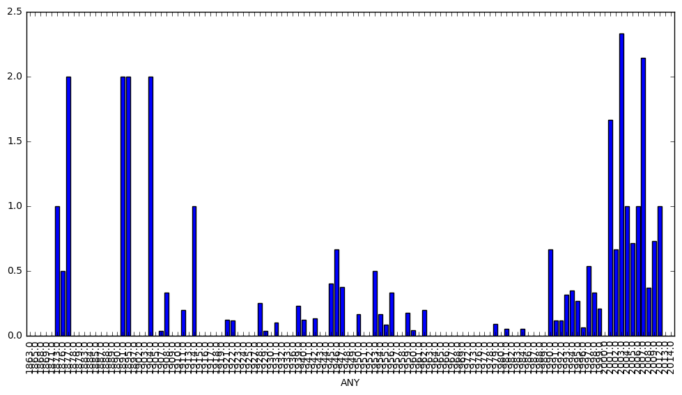

```python
any_sexe_df['RATIO'].plot.bar(color=['b'], width=0.75)
```

# 6. Resolució del problema. A partir dels resultats obtinguts, quines són les conclusions? Els resultats permeten respondre al problema?

Si observem les gràfiques obtingudes, veiem com les dades referents al segle XIX són poc significatives. A partir del començament del segle XX veiem com les dades ja són més significatives i s'observa com clarament la tendència és que hi hagi molts més carrers dedicats a homes que a dones. És a partir dels voltants de l'any 1990 quan es comença a veure un canvi de tendència, amb un creixement significatiu del nombre de carrers dedicats a dones, que al voltant de l'any 2000 arriba a una situació en que gairebé tenim una paritat en l'assignació de noms de carrers a personatges d'ambdós sexes.

Així doncs, podem concloure que es confirma la hipòtesi de que a mesura que la societat evoluciona cap a la igualtat entre ambdós sexes, això es reflecteix en l'assignació dels noms dels carrers a la Ciutat de Barcelona.

Si ens fixem en la representació gràfica del rati, observem com, efectivament, es confirmen aquestes tendències que hem observat a partir de l'any 1990.

# 7. Codi: Cal adjuntar el codi, preferiblement en R, amb el que s’ha realitzat la neteja, anàlisi i representació de les dades. Si ho preferiu, també podeu treballar en Python.

Aquest mateix full de Jupyter mostra tot el codi utilitzat.